# Plot Y1H for activation potential results testing Pho2 dependence

Bin He

2024-11-06 (updated 2024-11-08)

```r
require(tidyverse)
require(cowplot)
require(broom)
set.seed(12345)
old <- theme_set(theme_cowplot())
```

# Goal

Plotting Y1H data for testing the activation potential of PADDLE predicted regions in both ScPho4 and CgPho4. One specific goal in this study is to determine whether any of their effect is Pho2-dependent.

# Data

flow cytometry experiments were performed by Lindsey on 2024/10/30. gating was done on the Attune software and the stats were exported and organized

Note that in this dataset, R2 and R1 represent the cell and singlet gates, while R3 is the histogram gate to deal with some samples showing a bimodal distribution. In the analysis, Emily opted to use the singlet gate rather than the histogram gate. We can test both

```r
# read in sample information
sample <- read_tsv("20241030-EO-Y1H-dep-Pho2-sample.tsv",
                   # this tells the function that it should expect two character columns
                   col_types = "cc",
                   # this is to ensure if there are no values in some cell in the
                   # spreadsheet file, they will be translated to NA
                   na = character()) %>%
  # this is to change the name and group into vectors. optional
  mutate(name = fct_inorder(name), group = fct_inorder(group))
# read in the raw data
raw <- read_tsv("20241030-EO-Y1H-dep-Pho2-export.tsv",
                na = c("N/A", ""))
# transform the raw data
dat <- raw %>%
  # retain only the columns we need, and rename them for easy manipulation
  select(sample = Sample, gate = Gate, par = `X Parameter`,
         count = Count, median = `X Median`) %>%
  # filter by X Parameter and gates
  # we will retain both R1 and R3 gated cells for later experimenting
  filter(gate %in% c("R1", "R3"), par == "PHO5pr-mCherry - YL2-H") %>%
  # here, we separate the sample name into its constituent parts by "-":
  # 1. plasmid name; 2: host name; 3: replicate name
  separate(sample, into = c("plasmid", "host", "rep"), sep = "-") %>%
  # rename the host levels
  mutate(host = fct_recode(host,
                           PHO2 = "696", pho2 = "1009", 'pho2*' = "1009a"),
         # reorder the levels, for plotting
         host = fct_relevel(host, "PHO2", "pho2", "pho2*", "blank")) %>%
  # here, we annotate the raw data by merging it with the sample information
  # sheet, joining on the common column, i.e., plasmid
  left_join(sample, by = "plasmid")
```

Some data quality check

```r
# any sample with fewer than 3000 events?
dat %>% filter(count < 3000, gate == "R1")
```

| plasmid | host | rep | gate | par | count | median | group | name |
| --- | --- | --- | --- | --- | --- | --- | --- | --- |
| NA | blank | 1 | R1 | PHO5pr-mCherry - YL2-H | 10 | 121 | control | host |
| NA | blank | 2 | R1 | PHO5pr-mCherry - YL2-H | 11 | 366 | control | host |
| NA | blank | 3 | R1 | PHO5pr-mCherry - YL2-H | 16 | 529 | control | host |

```r
dat %>% filter(count < 3000, gate == "R3")
```

| plasmid | host | rep | gate | par | count | median | group | name |
| --- | --- | --- | --- | --- | --- | --- | --- | --- |
| 362 | pho2* | 3 | R3 | PHO5pr-mCherry - YL2-H | 2555 | 1714 | CgPho4 | CgAD |
| 362 | pho2* | 3 | R3 | PHO5pr-mCherry - YL2-H | 2555 | 1714 | CgPho4 | CgAD |
| NA | blank | 1 | R3 | PHO5pr-mCherry - YL2-H | 0 | NA | control | host |
| NA | blank | 1 | R3 | PHO5pr-mCherry - YL2-H | 0 | NA | control | host |
| 362 | pho2 | 3 | R3 | PHO5pr-mCherry - YL2-H | 1099 | 1536 | CgPho4 | CgAD |
| 362 | pho2 | 3 | R3 | PHO5pr-mCherry - YL2-H | 1099 | 1536 | CgPho4 | CgAD |
| 247 | PHO2 | 1 | R3 | PHO5pr-mCherry - YL2-H | 3 | 2711 | control | Gal4_DBD |
| 247 | PHO2 | 1 | R3 | PHO5pr-mCherry - YL2-H | 3 | 2711 | control | Gal4_DBD |
| NA | pho2 | 1 | R3 | PHO5pr-mCherry - YL2-H | 2 | 1396 | control | host |
| NA | pho2 | 1 | R3 | PHO5pr-mCherry - YL2-H | 2 | 1396 | control | host |

[output cut: 66 more lines]

Many samples seem to have few events in the histogram gate - this is understandable as the gate was created to isolate the “high expression” population from bimodally distributed samples. The R3 gate would include few events for samples where the reporter is not “on”.

Are negative controls negative?

```r
# blank wells
dat %>% filter(host == "blank") %>% arrange(gate)
```

| plasmid | host | rep | gate | par | count | median | group | name |
| --- | --- | --- | --- | --- | --- | --- | --- | --- |
| NA | blank | 1 | R1 | PHO5pr-mCherry - YL2-H | 10 | 121 | control | host |
| NA | blank | 2 | R1 | PHO5pr-mCherry - YL2-H | 11 | 366 | control | host |
| NA | blank | 3 | R1 | PHO5pr-mCherry - YL2-H | 16 | 529 | control | host |
| NA | blank | 1 | R3 | PHO5pr-mCherry - YL2-H | 0 | NA | control | host |
| NA | blank | 1 | R3 | PHO5pr-mCherry - YL2-H | 0 | NA | control | host |
| NA | blank | 2 | R3 | PHO5pr-mCherry - YL2-H | 2 | 2463 | control | host |
| NA | blank | 2 | R3 | PHO5pr-mCherry - YL2-H | 2 | 2463 | control | host |
| NA | blank | 3 | R3 | PHO5pr-mCherry - YL2-H | 3 | 1968 | control | host |
| NA | blank | 3 | R3 | PHO5pr-mCherry - YL2-H | 3 | 1968 | control | host |

```r
# no plasmid host background
dat %>% filter(plasmid == "NA", gate == "R1") %>% arrange(host)
```

| plasmid | host | rep | gate | par | count | median | group | name |
| --- | --- | --- | --- | --- | --- | --- | --- | --- |
| NA | PHO2 | 1 | R1 | PHO5pr-mCherry - YL2-H | 10000 | 82 | control | host |
| NA | PHO2 | 2 | R1 | PHO5pr-mCherry - YL2-H | 10000 | 81 | control | host |
| NA | PHO2 | 3 | R1 | PHO5pr-mCherry - YL2-H | 10000 | 90 | control | host |
| NA | pho2 | 1 | R1 | PHO5pr-mCherry - YL2-H | 10000 | 69 | control | host |
| NA | pho2 | 2 | R1 | PHO5pr-mCherry - YL2-H | 10000 | 69 | control | host |
| NA | pho2 | 3 | R1 | PHO5pr-mCherry - YL2-H | 10000 | 69 | control | host |
| NA | blank | 1 | R1 | PHO5pr-mCherry - YL2-H | 10 | 121 | control | host |
| NA | blank | 2 | R1 | PHO5pr-mCherry - YL2-H | 11 | 366 | control | host |
| NA | blank | 3 | R1 | PHO5pr-mCherry - YL2-H | 16 | 529 | control | host |

All seems good. Can proceed with plotting. Blank wells will be omitted from plotting.

# Analysis

## Plot all data

set some plotting variables

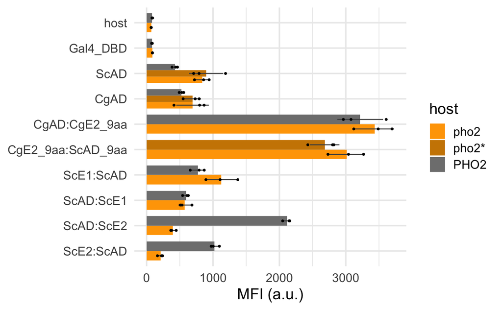

```r
# set the host levels for renaming them later
host.levels <- c("696" = "PHO2", "1009" = "pho2", "1009a" = "pho2*")

# set host colors
host.colors <- c("PHO2" = "gray50", "pho2" = "orange", "pho2*" = "orange3",
                 "blank" = "gray90")

# set group colors
grp.colors <- c("control" = "gray50",
                "ScPho4" = rgb(56, 118, 29, maxColorValue = 255),
                "CgPho4" = rgb(40, 130, 200, maxColorValue = 255),
                "Combo" = rgb(142, 120, 200, maxColorValue = 255))

# set position for bar plots
pd <- position_dodge(0.75)

# plot
p0 <- dat %>%
  # use R1 gate, and remove the blank wells
  filter(host != "blank", gate == "R1") %>%
  filter(name != "Gal4") %>%
  # reorder the levels of the host for plotting
  mutate(host = fct_relevel(host, "pho2", "pho2*", "PHO2")) %>%
  ggplot(aes(x = name, y = median, group = host)) +
  geom_bar(aes(fill = host), width = 0.75,
           stat = "summary", fun = "mean", position = pd) +
  stat_summary(fun.data = "mean_sdl", fun.args = list(mult = 1),
              geom = "linerange", color = "gray30", linewidth = 0.5,
              position = pd) +
  geom_point(position = pd, size = 0.75) +
  scale_x_discrete(limits = rev) +
  coord_flip() +
  scale_fill_manual(values = host.colors) +
  ylab("MFI (a.u.)") + xlab(NULL) +
  theme_minimal(base_size = 16)
p0
ggsave("20241107-EO-Y1H-Pho2-dep-plot.png", width = 6, height = 7)
```